# EDF 6938 Lecture 7: Binary Prediction Methods (II)

A.C. Thomas – FSSS

10/11/2015

One of the biggest reasons for the large presence of computer science’s foray into “machine learning” – what statisticians would have just called “statistics” for decades – is the field’s success in answering questions of prediction, particularly with to binary outcomes.

Last week we covered the most straightforward “statistical learning” method for prediction. This week we’ll discuss some methods that came from machine learning.

list of methods: - CART (with rpart) - LDA

## 1. Decision Trees and Flow Charts As Models

The simplest way we have to make a decision is to consider one factor at a time in sequence. We optimize a choice based on factors that have an order of importance.

Tree-based models take that principle and use it to divide up the data into a (somewhat) interpretable model. One package for this:

```r
install.packages("party")
```

Let’s bust it out and see how it works.

```r
library(party)
library(dplyr)
titanic <- read.table ("http://www.acthomas.ca/FSSS/data/titanic.txt", header=TRUE) %>%
  mutate (Class = as.factor(c("Crew","First","Second","Third")[Class + 1]))
tree.one <- ctree(as.factor(Survived) ~ ., data=titanic)
tree.one
```

```
##
##   Conditional inference tree with 9 terminal nodes
##
## Response:  as.factor(Survived)
## Inputs:  Class, Adult, Male
## Number of observations:  2201
##
## 1) Male <= 0; criterion = 1, statistic = 456.667
##   2) Class == {Third}; criterion = 1, statistic = 130.414
##     3)*  weights = 196
##   2) Class == {Crew, First, Second}
##     4) Class == {First}; criterion = 0.973, statistic = 9.367
##       5)*  weights = 145
##     4) Class == {Crew, Second}
##       6)*  weights = 129
## 1) Male > 0
##   7) Class == {Crew, Second, Third}; criterion = 1, statistic = 29.835
##     8) Adult <= 0; criterion = 1, statistic = 17.132
##       9) Class == {Second}; criterion = 1, statistic = 19.384
##         10)*  weights = 11
##       9) Class == {Third}
##         11)*  weights = 48
##     8) Adult > 0
##       12) Class == {Second, Third}; criterion = 1, statistic = 20.819
##         13) Class == {Third}; criterion = 0.965, statistic = 6.329
##           14)*  weights = 462
##         13) Class == {Second}
##           15)*  weights = 168
##       12) Class == {Crew}
##         16)*  weights = 862
##   7) Class == {First}
##     17)*  weights = 180
```

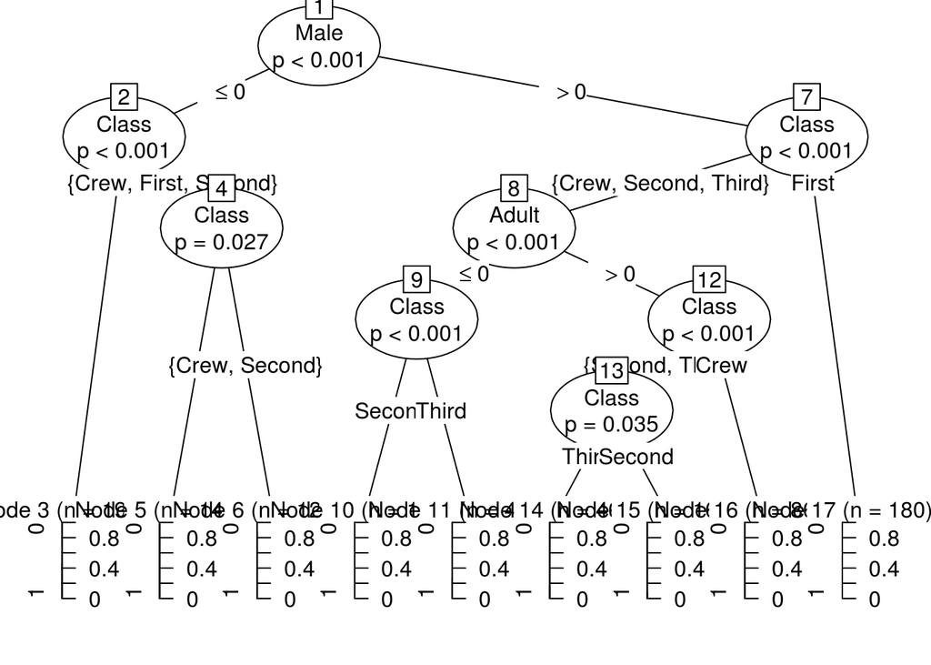

```r
plot(tree.one)
```

Extract the relevant predictions:

```r
unique.set <- titanic %>% dplyr::select (-Survived) %>% distinct
cbind (unique.set, prediction=Predict(tree.one, unique.set))
```

```
##     Class Adult Male prediction
## 1   First     1    1          0
## 2   First     1    0          1
## 3   First     0    1          0
## 4   First     0    0          1
## 5  Second     1    1          0
## 6  Second     1    0          1
## 7  Second     0    1          1
## 8  Second     0    0          1
## 9   Third     1    1          0
## 10  Third     1    0          0
## 11  Third     0    1          0
## 12  Third     0    0          0
## 13   Crew     1    1          0
## 14   Crew     1    0          1
```

Works better as linear, for the sake of this model:

```r
tree.two <- ctree(Survived ~ ., data=titanic)
tree.two
```

```
##
##   Conditional inference tree with 9 terminal nodes
##
## Response:  Survived
## Inputs:  Class, Adult, Male
## Number of observations:  2201
##
## 1) Male <= 0; criterion = 1, statistic = 456.667
##   2) Class == {Crew, First, Second}; criterion = 1, statistic = 130.414
##     3) Class == {First}; criterion = 0.973, statistic = 9.367
##       4)*  weights = 145
##     3) Class == {Crew, Second}
##       5)*  weights = 129
##   2) Class == {Third}
##     6)*  weights = 196
## 1) Male > 0
##   7) Class == {First}; criterion = 1, statistic = 29.835
##     8)*  weights = 180
##   7) Class == {Crew, Second, Third}
##     9) Adult <= 0; criterion = 1, statistic = 17.132
##       10) Class == {Second}; criterion = 1, statistic = 19.384
##         11)*  weights = 11
##       10) Class == {Third}
##         12)*  weights = 48
##     9) Adult > 0
##       13) Class == {Crew}; criterion = 1, statistic = 20.819
##         14)*  weights = 862
##       13) Class == {Second, Third}
##         15) Class == {Third}; criterion = 0.965, statistic = 6.329
##           16)*  weights = 462
##         15) Class == {Second}
##           17)*  weights = 168
```

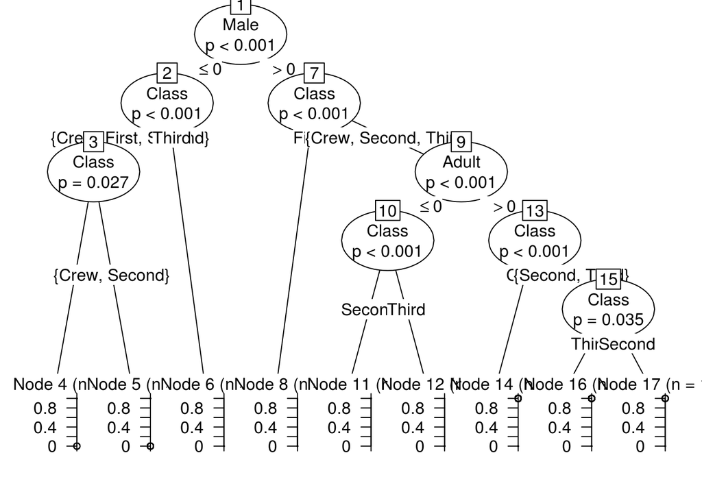

```r
plot(tree.two)
```

```r
cbind (unique.set, prediction=Predict(tree.two, unique.set))
```

```
##     Class Adult Male   Survived
## 1   First     1    1 0.34444444
## 2   First     1    0 0.97241379
## 3   First     0    1 0.34444444
## 4   First     0    0 0.97241379
## 5  Second     1    1 0.08333333
## 6  Second     1    0 0.87596899
## 7  Second     0    1 1.00000000
## 8  Second     0    0 0.87596899
## 9   Third     1    1 0.16233766
## 10  Third     1    0 0.45918367
## 11  Third     0    1 0.27083333
## 12  Third     0    0 0.45918367
## 13   Crew     1    1 0.22273782
## 14   Crew     1    0 0.87596899
```

This works for continuous data as well:

```r
print(load("wine-tests.RData"))
```

```
## [1] "red"   "white"
```

```r
head(red)
```

```
##   fixed.acidity volatile.acidity citric.acid residual.sugar chlorides
## 1           7.4             0.70        0.00            1.9     0.076
## 2           7.8             0.88        0.00            2.6     0.098
## 3           7.8             0.76        0.04            2.3     0.092
## 4          11.2             0.28        0.56            1.9     0.075
## 5           7.4             0.70        0.00            1.9     0.076
## 6           7.4             0.66        0.00            1.8     0.075
##   free.sulfur.dioxide total.sulfur.dioxide density   pH sulphates alcohol
## 1                  11                   34  0.9978 3.51      0.56     9.4
## 2                  25                   67  0.9968 3.20      0.68     9.8
## 3                  15                   54  0.9970 3.26      0.65     9.8
## 4                  17                   60  0.9980 3.16      0.58     9.8
## 5                  11                   34  0.9978 3.51      0.56     9.4
## 6                  13                   40  0.9978 3.51      0.56     9.4
##   quality
## 1       5
## 2       5
## 3       5
## 4       6
## 5       5
## 6       5
```

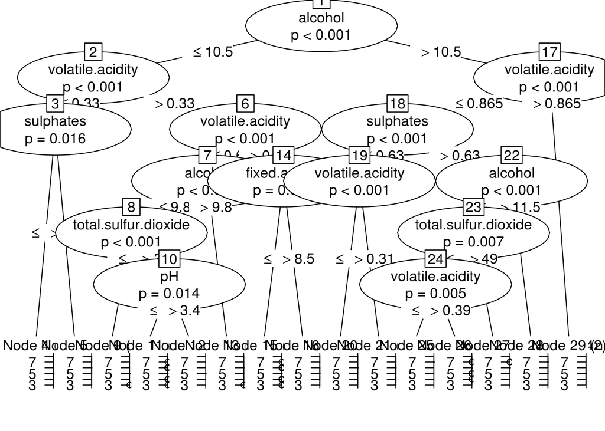

```r
red.tree <- ctree (quality ~ ., data=red)
plot(red.tree)
```

This is unwieldy to show, so I’m exporting it to a PDF for easier viewing.

```r
pdf("red-plot.pdf", height=28, width=28)
plot(red.tree)
dev.off()
```

```r
white.tree <- ctree (quality ~ ., data=white)
pdf("white-plot.pdf", height=48, width=48)
plot(white.tree)
dev.off()
```

Lots of variables! Lots of choices. This partitioning is being done by a simple method that searches for statistically significant differences in-sample.

```r
radon <- read.table ("http://www.acthomas.ca/FSSS/data/mn-radon.txt", header=TRUE) %>% mutate (badradon = 1*(radon >= 5))

radon.tree <- ctree (log.radon ~ as.factor(county) + floor + log.uranium, data=radon)
radon.tree
```

```
##
##   Conditional inference tree with 5 terminal nodes
##
## Response:  log.radon
## Inputs:  as.factor(county), floor, log.uranium
## Number of observations:  919
##
## 1) log.uranium <= -0.1632922; criterion = 1, statistic = 187.988
##   2) floor <= 0; criterion = 0.991, statistic = 28.595
##     3)*  weights = 272
##   2) floor > 0
##     4)*  weights = 56
## 1) log.uranium > -0.1632922
##   5) floor <= 0; criterion = 1, statistic = 84.691
##     6) log.uranium <= -0.02414516; criterion = 1, statistic = 96.539
##       7)*  weights = 227
##     6) log.uranium > -0.02414516
##       8)*  weights = 267
##   5) floor > 0
##     9)*  weights = 97
```

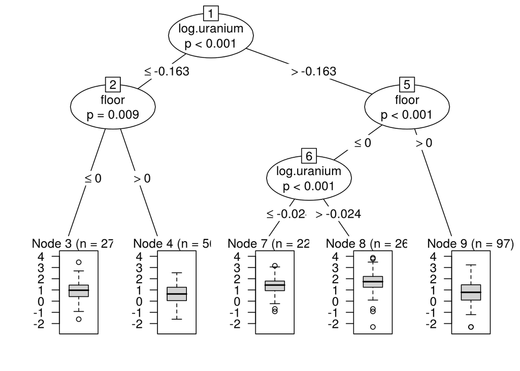

```r
plot (radon.tree)
```

Not always the most revealing splits, not always the biggest bit of information. Let’s do another categorical one:

```r
library(MASS)
```

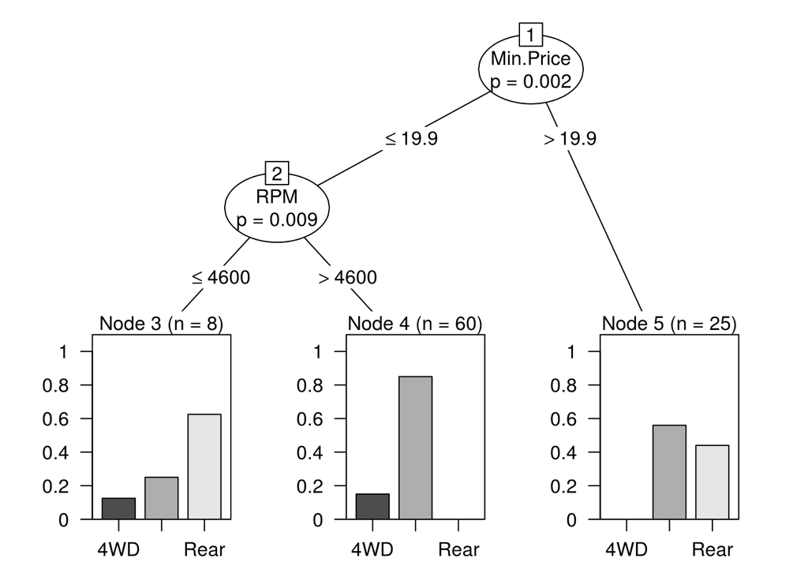

```r
car.tree <- ctree (DriveTrain ~ ., data=Cars93)
plot(car.tree)
```

Lots of variables – minimal depth. What’s driving this? Some rule based on the number of rows to avoid overfitting? (Yes.) Bonferroni correction? (Yes.) Out-of-sample validity? (No!)

## Cross-Validation with Trees

Another package has a built-in way of doing this; let’s try it instead.

```r
install.packages("tree")
```

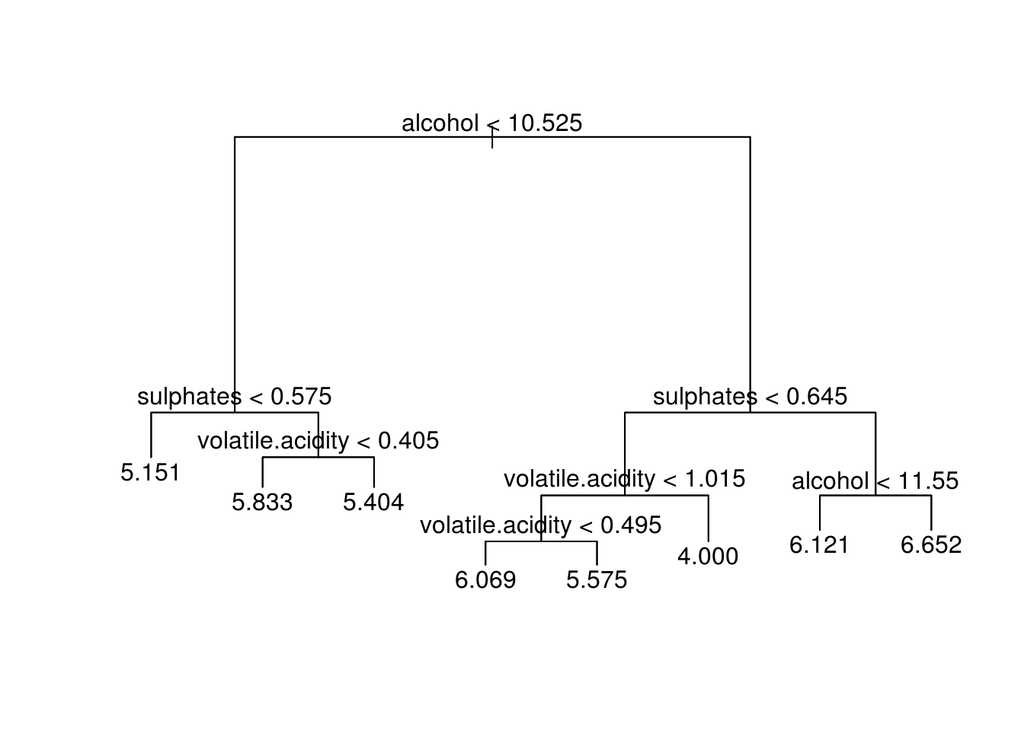

```r
library("tree")
red.tree.2 <- tree (quality ~ ., data=red)
plot (red.tree.2)
text (red.tree.2)
```

It’s ugly and I don’t like that. But it does work.

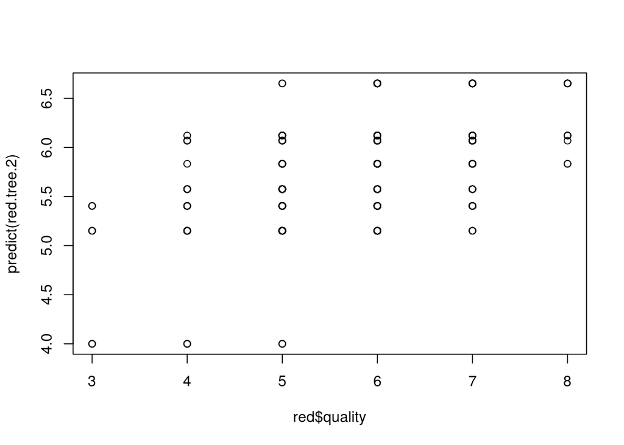

```r
plot (red$quality, predict(red.tree.2))
```

Sort of. Different trees!

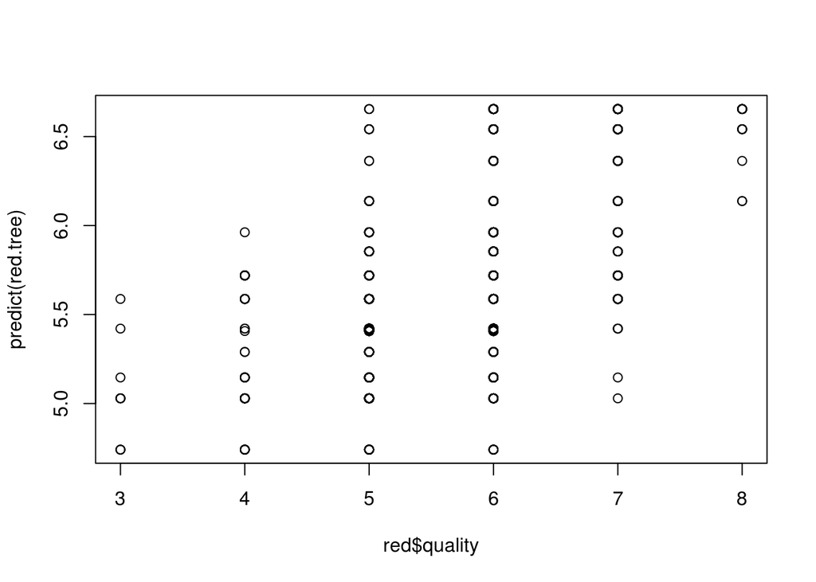

```r
plot (red$quality, predict(red.tree))
```

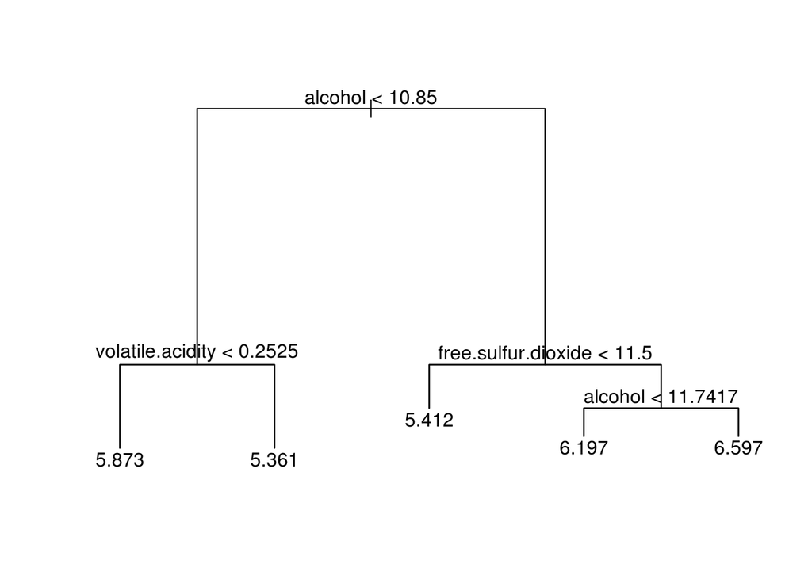

```r
white.tree.2 <- tree (quality ~ ., data=white)
plot (white.tree.2)
text (white.tree.2)
```

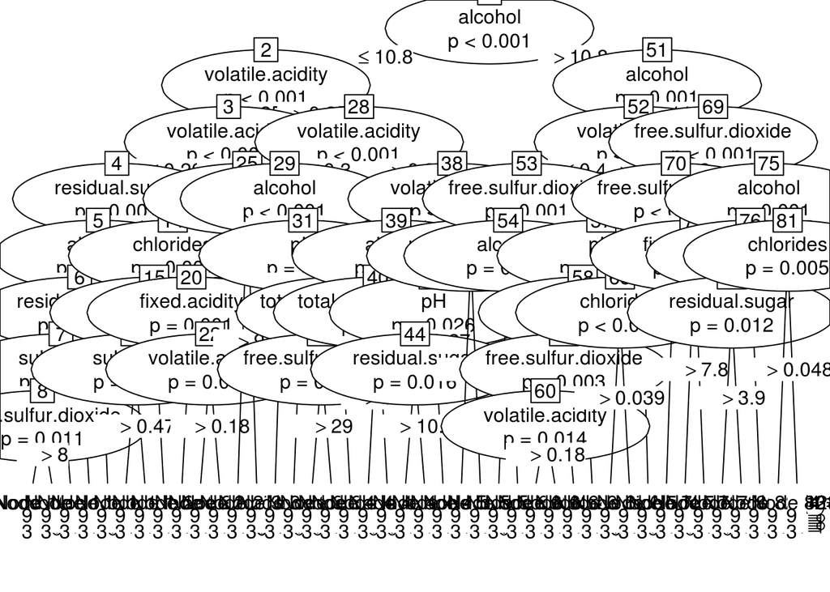

```r
## Compare to...
plot(white.tree)
```